# Analysis of my Triathlon Season: 2019-2020

Cameron Isaacs-Trepanier

[figure not shown]

```r
#load tidyverse, lubridate, viridisLite, and RColorBrewer
library(tidyverse)
library(lubridate)
library(viridisLite)
library(RColorBrewer)

workouts <- read_csv("workouts.csv", na = "NA")

#remove cols not needed
workouts <- workouts %>%
  select(-c("WorkoutDescription", "CoachComments", "AthleteComments",
            "VelocityMax", "CadenceMax", "TorqueAverage", "TorqueMax",
            "HRZone8Minutes", "HRZone9Minutes", "HRZone10Minutes",
            "PWRZone7Minutes", "PWRZone8Minutes", "PWRZone9Minutes",
            "PWRZone10Minutes"))

#rename cols to decrease ambiguity
workouts <- workouts %>%
  rename(IntensityFactor = IF, TrainingStressScore = TSS,
         PerceivedExertion = Rpe)

#Include only observations that were planned activities (i.e. not comments)
workouts <- workouts %>%
  filter((WorkoutType %in% c("Swim", "Bike", "Run", "Strength")) |
           str_detect(Title, "Yoga"), !str_detect(WorkoutType, "Day Off"))

#Change value "Other" to "Yoga"
workouts <- workouts %>%
  mutate(WorkoutType = replace(WorkoutType, WorkoutType == "Other", "Yoga"))

#add col for completion (T/F) of workout
workouts <- workouts %>%
  mutate(complete = !is.na(TimeTotalInHours))

#add col for km/h, min/km, and min/100meters (standard pace measurements for
#bike, run, and swim, respectively)
workouts <- workouts %>%
  mutate(VelocityAverage =
         replace(VelocityAverage, VelocityAverage == 0.000000, NA)) %>%
  mutate(km.h = VelocityAverage*3.6, min.km = 100/(VelocityAverage*6),
         sec.100m = 100/VelocityAverage)

#add month-year col
workouts <- workouts %>%
  mutate(Month = format(WorkoutDay, "%m-%y"))

#add week col
workouts <- workouts %>%
  mutate(Week = cut.Date(WorkoutDay, "weeks"))

#summary data
TotalPlannedWorkouts <- workouts %>%
  summarize(TotalPlanned = nrow(workouts))

CompletionRate <- sum(workouts$complete == TRUE)/TotalPlannedWorkouts$TotalPlanned*100

TotalDistanceTraveled <- workouts %>%
  summarize(DistanceInKm = sum(DistanceInMeters, na.rm = TRUE)/1000)

TotalTimeOverall <- workouts %>%
  summarize(TotalHours = sum(TimeTotalInHours, na.rm = TRUE))

PlannedBySport <- workouts %>%
  group_by(WorkoutType) %>%
  summarize(PlannedWorkouts = n()) %>%
  mutate(PercentOfTotal = PlannedWorkouts/TotalPlannedWorkouts$TotalPlanned*100)

#colour blind friendly colour palette
cbbPalette <- c("#000000", "#E69F00", "#56B4E9", "#009E73", "#F0E442", "#0072B2", "#D55E00", "#CC79A7")
```

#### Mini recap

This season went from **2019-10-07 to 2020-10-01**. There were of course many trials and tribulations due to the pandemic. Namely, my swimming was sporadic and my strength training was almost non-existent once the lockdown hit. All the races I had planned (there were 4!) were canceled, so I had very little in terms of results to show. Nonetheless, I was able to complete two socially-distanced races and several time trials. I will post the results of those events at the end.

What will follow in this report is a general overview of my training year. We will take an overall look at how much training I did, what kind of training I did, and how the amount/kind of training looks for each major activity in triathlon (biking, running, and swimming). Most of the sections will include totals (eg. total time or distance), which will be useful when I want to compare the amount of training I did this year to the amount in future years. The bread and butter of this report will be looking at the percentage distribution within this year.  
My largest priority race for this year was Ironman Muskoka 70.3. This race consists of 1.9 km of swimming, 90 km of biking, and 21.1 km (half-marathon) of running. I had a target time of 05:00 hours or less: 00:35 minutes swimming, 02:40 biking, 01:40 running, and 00:05 transitioning. My training was tailored to those race distances and those target times. Let’s see how well I did with following that plan despite never getting to race in Muskoka this year!

#### Completion rate

Let’s first take a look at how many workouts I had planned throughout the year, and how many of those workouts I successfully completed. I will assume that an activity with not recorded time is one that I did not complete, and the opposite is true for activities with a recorded time. It looks like a total of **498** workouts were planned. I completed **365** workouts (one for every day of the year!!!), for a completion rate of **73%**. That’s not bad considering I had to cancel many workouts because of the lockdown and to compensate for fatigue from heavier training weeks.

Taking a look at graph A, we see that I had more bike workouts than any other workout type. That makes sense since it makes up the majority of the race. Second comes running, but third is strength instead of swimming. Scheduling this many strength sessions was intentional because this year I prioritized a strength routine to avoid last year’s injuries from derailing my training. Now, how often did I complete those planned workouts for each sport. It looks like I completed 80% or more of my biking and running workouts. That is really good. It also makes sense because those activities were not limited by the lockdown for the most part. I completed over 70% of my planned swim workouts, which I did not think was true before making this graph. I did not swim for all of March and April, but I did make a point to swim in the lake once it got warm enough. Strength workouts took a big hit because I lack the necessary equipment at home and gyms have been a no-go since March. Now yoga is really an area where I have no excuse. I often put those aside in favour of other workouts. I need to get better at completing those when I plan them. After all, mobility from yoga helps in all aspects of triathlon.

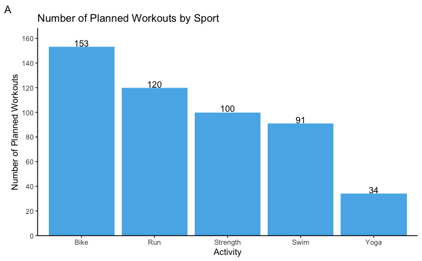

```r
workouts %>%
  ggplot(aes(WorkoutType)) +
  geom_bar(fill = cbbPalette[3]) +
  geom_text(aes(label = ..count..), stat = "count", vjust = -0.1) +
  theme_classic() +
  labs(title = "Number of Planned Workouts by Sport", x = "Activity", y = "Number of Planned Workouts", tag = "A") +
  scale_y_continuous(breaks = seq(0, 160, 20), expand = expansion(mult = c(0, 0.1)))
```

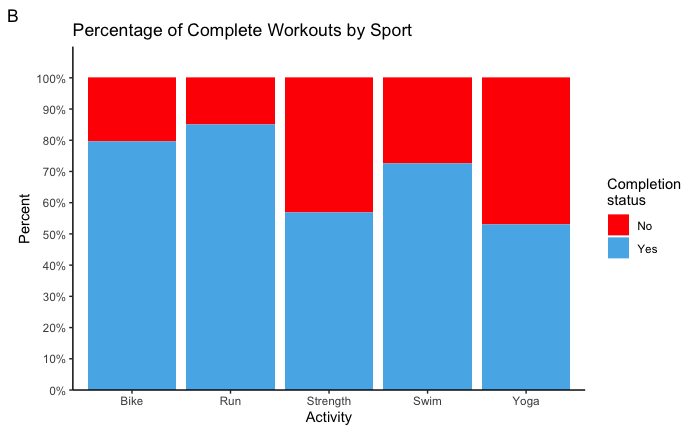

```r
workouts %>%
  ggplot(aes(WorkoutType, fill = complete)) +
  geom_bar(position = "fill") +
  theme_classic() +
  scale_fill_manual(labels = c("No", "Yes"), values = c("Red", cbbPalette[3])) +
  labs(title = "Percentage of Complete Workouts by Sport", x = "Activity", y = "Percent",
       fill = "Completion \nstatus", tag = "B") +
  scale_y_continuous(labels = scales::percent_format(accuracy = 1), breaks = seq(0, 1, 0.1),
                     expand = expansion(mult = c(0, 0.1)))
```

#### Time commitment

Now, we will take a look at how much time I actually spent training overall and for each activity. I trained for a total of **307** hours. It’s no surprise that I trained most of the hours in biking, followed by running then swimming. In a well executed season, the proportion of total time between the three major sports should be similar to the proportion between your goal times for each sport. That means 12% for swimming, 53% for biking, and 35% for running. That’s really close to what we see in graph B! However, I took a bit of time from running and added it to swimming. That’s because swimming is my weakest sport, and I knew a lot of improvements could be made with extra time in the water. Looks like I did really well with dividing my time.

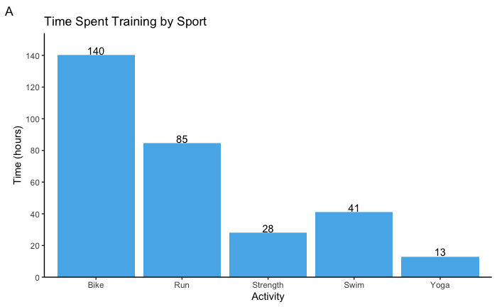

```r
TimeBySport <- workouts %>%
  group_by(WorkoutType) %>%
  summarize(TotalHours = sum(TimeTotalInHours, na.rm = TRUE))

TimeBySport %>%
  ggplot(aes(WorkoutType, TotalHours)) +
  geom_col(fill = cbbPalette[3]) +
  geom_text(aes(label = round(TotalHours, 0)), vjust = -0.1) +
  theme_classic() +
  labs(title = "Time Spent Training by Sport", x = "Activity", y = "Time (hours)", tag = "A") +
  scale_y_continuous(breaks = seq(0, 160, 20), expand = expansion(mult = c(0, 0.1)))
```

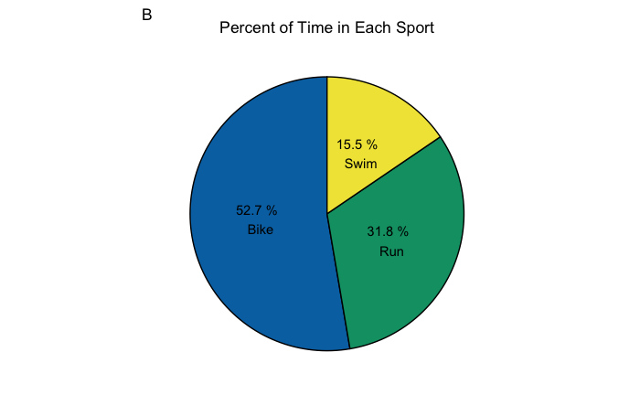

```r
TimeBySport %>%
  filter(WorkoutType %in% c("Bike", "Swim", "Run")) %>%
  ggplot(aes(x = "", TotalHours, fill = factor(WorkoutType))) +
  geom_bar(stat = "identity", colour = "black") +
  geom_text(aes(label = paste(round(TotalHours/sum(TotalHours)*100, 1), "%", "\n", WorkoutType)),
            position = position_stack(vjust = 0.5)) +
  coord_polar(theta = "y") +
  theme(
    line = element_blank(),
    rect = element_blank(),
    axis.title = element_blank(),
    axis.ticks = element_blank(),
    axis.text = element_blank(),
    legend.position = "none",
    plot.title = element_text(hjust = 0.5)) +
  labs(title = "Percent of Time in Each Sport", tag = "B") +
  scale_fill_manual(values = c(cbbPalette[6], cbbPalette[4], cbbPalette[5]))
```

#### Distance traveled

Time is usually the best way to plan your training because it helps us schedule our lives outside of training. The amount of time I can commit to training is usually my limiting factor. However, distance is still a very useful metric because it helps us train specifically for the race distances we plan to cover in competition. Let’s take a look at my overall distance covered, distance in each sport, and the proportion each sport that makes up the total distance. This season, I covered a total distance of 4516 km. That is about half way accross Canada (9306 km). Not surprisingly, biking makes up for 3543 km of the total. As with times, a well executed training season shows roughly equivalent proportions between the distances covered in training and those of your highest priority race for that season. That means roughly 2% for swimming, 80% for biking, and 19% for running. Take a look at graph B. That is almost spot on! Again, a bit more was done in swimming, but that was by design.

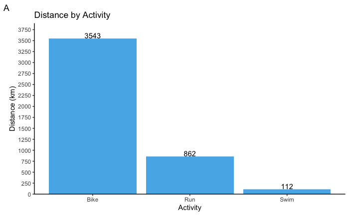

```r
DistanceBySport <- workouts %>%
  filter(WorkoutType %in% c("Bike", "Run", "Swim")) %>%
  group_by(WorkoutType) %>%
  summarize(DistanceInKm = sum(DistanceInMeters, na.rm = TRUE)/1000)

DistanceBySport %>%
  ggplot(aes(WorkoutType, DistanceInKm)) +
  geom_col(fill = cbbPalette[3]) +
  geom_text(aes(label = round(DistanceInKm, 0)), vjust = -0.1) +
  labs(title = "Distance by Activity", x = "Activity", y = "Distance (km)", tag = "A") +
  theme_classic() +
  scale_y_continuous(breaks = seq(0, 4000, 250), expand = expansion(mult = c(0, 0.1)))
```

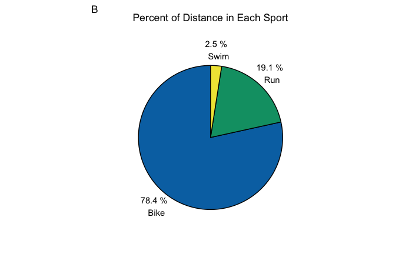

```r
DistanceBySport %>%
  ggplot(aes(x = "", DistanceInKm, fill = factor(WorkoutType))) +
  geom_bar(stat = "identity", colour = "black") +
  geom_text(aes(x = 1.65, label = paste(round(DistanceInKm/sum(DistanceInKm)*100, 1), "%", "\n", WorkoutType)),
            position = position_stack(vjust = 0.5)) +
  coord_polar(theta = "y") +
  theme(
    line = element_blank(),
    rect = element_blank(),
    axis.title = element_blank(),
    axis.ticks = element_blank(),
    axis.text = element_blank(),
    legend.position = "none",
    plot.title = element_text(hjust = 0.5)) +
  labs(title = "Percent of Distance in Each Sport", tag = "B") +
  scale_fill_manual(values = cbbPalette[c(6,4,5)])
```

#### Heart rate zones

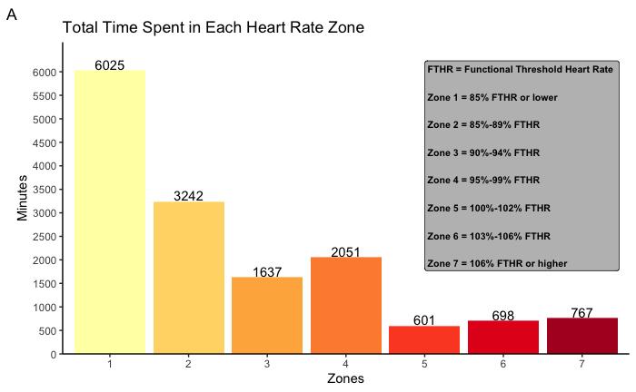

```r
TotalTimeInHRZones <- workouts %>%
  select(17:23) %>%
  summarize_all(sum, na.rm = TRUE) %>%
  pivot_longer(everything(), names_to = "Zones", values_to = "Minutes")

TotalTimeInHRZones %>%
  ggplot(aes(Zones, Minutes, fill = Zones)) +
  geom_col() +
  geom_text(aes(label = round(Minutes, 0)), vjust = -0.1) +
  annotate(geom = "label", x = 5, y = 4000, hjust = 0, size = 2.8, fill = "grey", fontface = "bold",
           label = "FTHR = Functional Threshold Heart Rate
           \nZone 1 = 85% FTHR or lower
           \nZone 2 = 85%-89% FTHR
           \nZone 3 = 90%-94% FTHR
           \nZone 4 = 95%-99% FTHR
           \nZone 5 = 100%-102% FTHR
           \nZone 6 = 103%-106% FTHR
           \nZone 7 = 106% FTHR or higher") +
  theme_classic() +
  theme(legend.position = "none") +
  labs(title = "Total Time Spent in Each Heart Rate Zone", tag = "A") +
  scale_x_discrete(labels = c(1:7)) +
  scale_y_continuous(breaks = seq(0, 6000, 500), expand = expansion(mult = c(0, 0.1))) +
  scale_fill_brewer(palette = "YlOrRd")
```

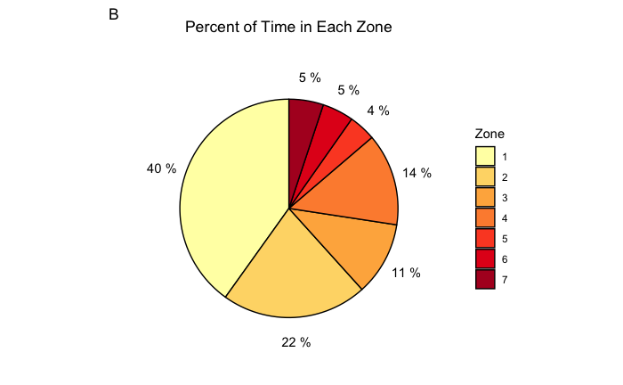

```r
TotalTimeInHRZones %>%
  ggplot(aes(x = "", Minutes, fill = factor(Zones))) +
  geom_bar(stat = "identity", colour = "black") +
  geom_text(aes(x = 1.65, label = paste(round(Minutes/sum(Minutes)*100, 0), "%")),
            position = position_stack(vjust = 0.5)) +
  coord_polar(theta = "y") +
  theme(
    line = element_blank(),
    rect = element_blank(),
    axis.title = element_blank(),
    axis.ticks = element_blank(),
    axis.text = element_blank(),
    plot.title = element_text(hjust = 0.5)) +
  labs(title = "Percent of Time in Each Zone", fill = "Zone", tag = "B") +
  scale_fill_brewer(palette = "YlOrRd", labels = c(1:7))
```

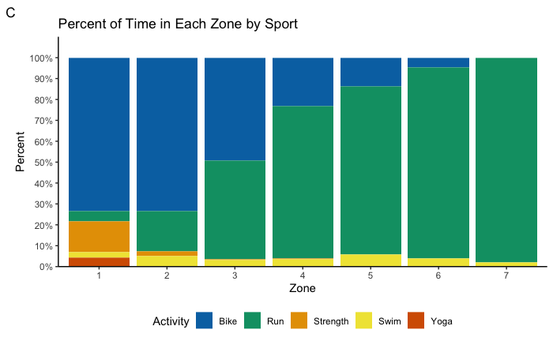

```r
TimeInHRZoneBySport <- workouts %>%
  group_by(WorkoutType) %>%
  select(WorkoutType, 17:23) %>%
  summarize_all(sum, na.rm = TRUE) %>%
  pivot_longer(!WorkoutType, names_to = "HRZone", values_to = "Minutes")

TimeInHRZoneBySport %>%
  ggplot(aes(HRZone, Minutes, fill = WorkoutType)) +
  geom_col(position = "fill") +
  theme_classic() +
  theme(legend.position = "bottom") +
  scale_x_discrete(labels = c(1:7)) +
  scale_y_continuous(labels = scales::percent_format(accuracy = 1), breaks = seq(0, 1, 0.1),
                     expand = expansion(mult = c(0, 0.1))) +
  scale_fill_manual(values = cbbPalette[c(6,4,2,5,7)]) +
  labs(title = "Percent of Time in Each Zone by Sport", x = "Zone", y = "Percent", fill = "Activity", tag = "C")
```

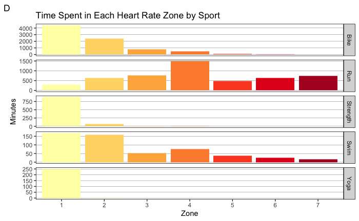

```r
TimeInHRZoneBySport %>%
  ggplot(aes(HRZone, Minutes, fill = HRZone)) +
  geom_col() +
  theme(panel.background = element_rect(fill = NA),
        panel.grid.major.y = element_line(colour = "black", size = 0.1,),
        panel.grid.major.x = element_blank(),
        panel.border = element_rect(colour = "black", fill = NA),
        strip.background = element_rect(colour = "black"),
        legend.position = "none") +
  labs(title = "Time Spent in Each Heart Rate Zone by Sport", x = "Zone", tag = "D") +
  scale_x_discrete(labels = c(1:7)) +
  scale_fill_brewer(palette = "YlOrRd") +
  facet_grid(rows = vars(WorkoutType), scales = "free_y")
```

#### Bike Power

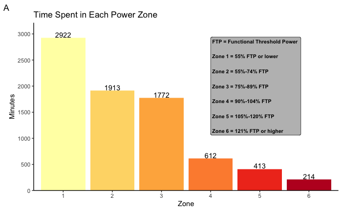

```r
PWRZoneMinutes <- workouts %>%
  filter(WorkoutType == "Bike") %>%
  select(24:29) %>%
  summarize_all(sum, na.rm = TRUE) %>%
  pivot_longer(everything(), names_to = "PWRZone", values_to = "Minutes")

PWRZoneMinutes %>%
  ggplot(aes(PWRZone, Minutes, fill = PWRZone)) +
  geom_col() +
  geom_text(aes(label = round(Minutes, 0)), vjust = -0.1) +
  annotate(geom = "label", x = 4, y = 2000, hjust = 0, size = 2.8, fill = "grey", fontface = "bold",
           label = "FTP = Functional Threshold Power
           \nZone 1 = 55% FTP or lower
           \nZone 2 = 55%-74% FTP
           \nZone 3 = 75%-89% FTP
           \nZone 4 = 90%-104% FTP
           \nZone 5 = 105%-120% FTP
           \nZone 6 = 121% FTP or higher") +
  theme_classic() +
  theme(legend.position = "none") +
  labs(title = "Time Spent in Each Power Zone", x = "Zone", tag = "A") +
  scale_x_discrete(labels = c(1:6)) +
  scale_y_continuous(breaks = seq(0, 3000, 500), expand = expansion(mult = c(0, 0.1))) +
  scale_fill_brewer(palette = "YlOrRd")
```

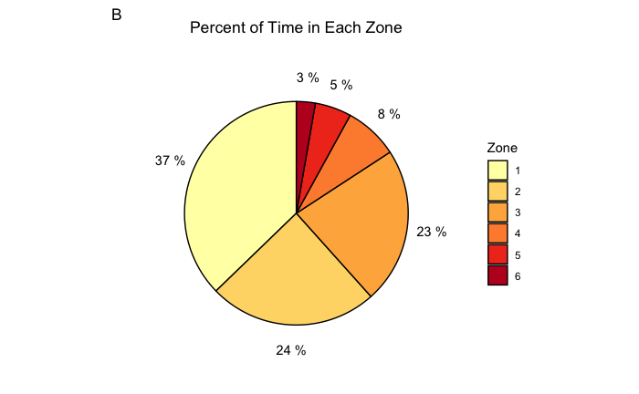

```r
PWRZoneMinutes %>%
  ggplot(aes(x = "", Minutes, fill = factor(PWRZone))) +
  geom_bar(stat = "identity", colour = "black") +
  geom_text(aes(x = 1.65, label = paste(round(Minutes/sum(Minutes)*100, 0), "%")),
            position = position_stack(vjust = 0.5)) +
  coord_polar(theta = "y") +
  theme(
    line = element_blank(),
    rect = element_blank(),
    axis.title = element_blank(),
    axis.ticks = element_blank(),
    axis.text = element_blank(),
    plot.title = element_text(hjust = 0.5)) +
  labs(title = "Percent of Time in Each Zone", fill = "Zone", tag = "B") +
  scale_fill_brewer(palette = "YlOrRd", labels = c(1:6))
```

#### Training Stress Score

Training stress score is like the ultimate metric for determining how hard a workout is. Training stress score takes into account heart rate, power, distance, and duration to calculate a number value of how much stress your body experienced during a workout. Greater stress from a workout usually means greater fitness gains (if you take the time to recover properly). The downside is that it’s a complicated metric calculated from several variables, and it cannot be used in a training session to gauge how hard you are working. Taking a look at how much training stress I incurred between the three major sports, we see that there is a much more even distribution between the sports than in the other metrics. This means that despite differences in time, heart rate, and distance between the sports, there was a more equal distribution in the amount of stress my body experienced between the sports. Given I am only in my second year of serious triathlon training, this kind of makes sense. I have plenty of room to improve in all three sports. Therefore, stressing my body equally in all three sports should pay off in significant fitness gains across swimming, biking, and running. It will be interesting to see over the years if the training stress distribution changes to favour one of the sports.

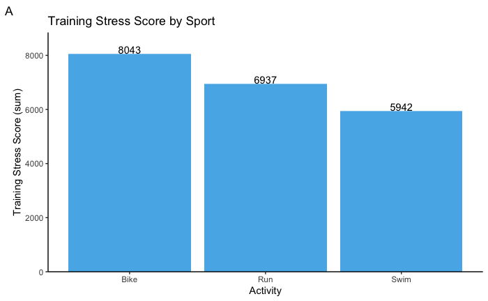

```r
TSSBySport <- workouts %>%
  select(WorkoutType, TrainingStressScore) %>%
  group_by(WorkoutType) %>%
  filter(WorkoutType %in% c("Bike", "Swim", "Run")) %>%
  summarize(TotalTSS = sum(TrainingStressScore, na.rm = TRUE))

TSSBySport %>%
  ggplot(aes(WorkoutType, TotalTSS)) +
  geom_col(fill = cbbPalette[3]) +
  geom_text(aes(label = round(TotalTSS, 0)), vjust = -0.1) +
  theme_classic() +
  labs(title = "Training Stress Score by Sport", x = "Activity", y = "Training Stress Score (sum)", tag = "A") +
  scale_y_continuous(expand = expansion(mult = c(0, 0.1)))
```

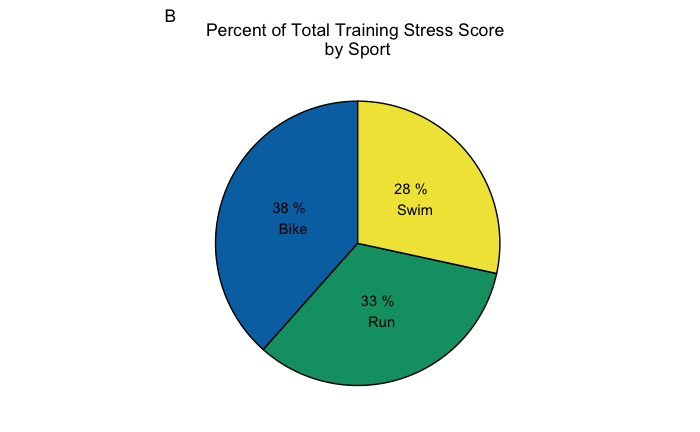

```r
TSSBySport %>%
  ggplot(aes(x = "", TotalTSS, fill = factor(WorkoutType))) +
  geom_bar(stat = "identity", colour = "black") +
  geom_text(aes(label = paste(round(TotalTSS/sum(TotalTSS)*100, 0), "%", "\n", WorkoutType)),
            position = position_stack(vjust = 0.5)) +
  coord_polar(theta = "y") +
  theme(
    line = element_blank(),
    rect = element_blank(),
    axis.title = element_blank(),
    axis.ticks = element_blank(),
    axis.text = element_blank(),
    plot.title = element_text(hjust = 0.5),
    legend.position = "none") +
  labs(title = "Percent of Total Training Stress Score \nby Sport", fill = "Activity", tag = "B") +
  scale_fill_manual(values = cbbPalette[c(6,4,5)])
```

#### Race results

I ended up doing 3 races in 2020! That is a miracle given how many were canceled. My first race was organized my Hart House at the University of Toronto. The format is built for beginners to get a feel for triathlons and for more experienced athletes to test themselves on a different format. Each sport has a 15 minute time limit, and the goal is to go as far as you can in those 15 minutes. Usually, transitions between sports count towards your time, but that obviously does not apply to this triathlon. My goal was to just go as hard as I can for the whole 15 minutes, and my results reflect that. I managed under 2 minutes per 100 meters in the swim, an astounding 38.48 km/h on the bike (it was a stationary, so these results could be contested), and just over 4 min/km on the run! This gave me confidence that I could race near the paces I was aiming for. Now, let’s look at some longer race distances to see if the paces hold up. Takeaway: **my body can go the speeds I want it to**

```r
HartHouseSwim <- c("00:15:00", 800, 112.6)
HartHouseBike <- c("00:15:00", 9.62, 38.48)
HartHouseRun <- c("00:15:00", 3.64, 4.1)
HartHouseTriDistance <- c(800, 9.62, 3.64)
HartHouseTriPace <- c(112.6, 38.48, 4.1)
HartHouseResults <- cbind(HartHouseSwim, HartHouseBike, HartHouseRun)
colnames(HartHouseResults) <- c("Swim", "Bike", "Run")
rownames(HartHouseResults) <- c("Time (hh:mm:ss)", "Distance (m, km, km)", "Pace (sec/100m, km/h, min/km)")
knitr::kable(HartHouseResults, caption = "**Hart House Triathlon Results (Feb 29, 2020):** No transitions.", align = "ccc")
```

**Hart House Triathlon Results (Feb 29, 2020):** No transitions.

|  | Swim | Bike | Run |
| --- | --- | --- | --- |
| Time (hh:mm:ss) | 00:15:00 | 00:15:00 | 00:15:00 |
| Distance (m, km, km) | 800 | 9.62 | 3.64 |
| Pace (sec/100m, km/h, min/km) | 112.6 | 38.48 | 4.1 |

```r
CaledonLongCourseSwim <- c("00:33:36", 1.657, 110.5)
CaledonLongCourseBike <- c("02:00:45", 52.6, 25.92)
CaledonLongCourseRun <- c("01:07:49", 13.8, 4.93)
CaledonLongCourseResults <- cbind(CaledonLongCourseSwim, CaledonLongCourseBike, CaledonLongCourseRun)
rownames(CaledonLongCourseResults) <- c("Time (hh:mm:ss)", "Distance (km)", "Pace (sec/100m, km/h, min/km)")
colnames(CaledonLongCourseResults) <- c("Swim", "Bike", "Run")
knitr::kable(CaledonLongCourseResults, caption = "**Caledon Long Course Results (Aug 02, 2020):** No transitions. Independent starts", align = "ccc")
```

**Caledon Long Course Results (Aug 02, 2020):** No transitions. Independent starts

|  | Swim | Bike | Run |
| --- | --- | --- | --- |
| Time (hh:mm:ss) | 00:33:36 | 02:00:45 | 01:07:49 |
| Distance (km) | 1.657 | 52.6 | 13.8 |
| Pace (sec/100m, km/h, min/km) | 110.5 | 25.92 | 4.93 |

```r
CaledonOlympicSwin <- c("00:24:50", 1.305, 113.7)
CaledonOlympicBike <- c("01:12:46", 35, 28.64)
CaledonOlympicRun <- c("00:35:18", 8.3, 4.28)
CaledonOlympicResults <- cbind(CaledonOlympicSwin, CaledonOlympicBike, CaledonOlympicRun)
rownames(CaledonOlympicResults) <- c("Time (hh:mm:ss)", "Distance (km)", "Pace (sec/100m, km/h, min/km)")
colnames(CaledonOlympicResults) <- c("Swim", "Bike", "Run")
knitr::kable(CaledonOlympicResults, caption = "**Caledon Olympic Triathlon Results (Aug 30, 2020):** No transitions. Independent starts", align = "ccc")
```

**Caledon Olympic Triathlon Results (Aug 30, 2020):** No transitions. Independent starts

|  | Swim | Bike | Run |
| --- | --- | --- | --- |
| Time (hh:mm:ss) | 00:24:50 | 01:12:46 | 00:35:18 |
| Distance (km) | 1.305 | 35 | 8.3 |
| Pace (sec/100m, km/h, min/km) | 113.7 | 28.64 | 4.28 |

#### Conclusion

This year was a strange year all around. I trained consistently in each sport until March. Almost nothing stood in my way of completing a workout. If I was tired and didn’t want to walk in the cold to go swim, I told myself to just get ready and step outside. Then it was much easier to just keep going. If I was tired from waking up at 6:00 am to get a bike ride in, I told myself to just get up for 5 minutes and drink a coffee by the window. Then, I was awake and could hop on the bike. Then all of a sudden pools and gyms closed, races were canceled, and I was unsure if I could even run or bike outside. On top of this, I was in the middle of preparing for my Master’s defence that was set to take place virtually on April 1st! This meant my trainer and I had to get creative, adjust our expectations, and set goals a bit differently. I moved to doing a lot of indoor bike rides and more runs. Once the lake was warm enough to swim in with a wetsuit, I started swimming there. We also improvised some at-home strength routines, so I could stay on top of injury prevention. This flexibility allowed me to keep some momentum and capitalize on the things I could do, rather than dwell on the things I could not. In the end, I was able to complete three races in the season, and my performance in them was something to be proud of. On top of that, I have some great takeaways to help me improve my 2020/2021 triathlon season.